# Лабораторная работа №11

Управление загрузкой системы

Юсупова К. Р.

Российский университет дружбы народов, Москва, Россия

# Информация

## Докладчик

- Юсупова Ксения Равилевна
- Российский университет дружбы народов
- Номер студенческого билета- 1132247531
- [1132247531@pfur.ru]

# Вводная часть

## Цель работы

Получить навыки работы с загрузчиком системы GRUB2.

# Выполнение лабораторной работы

Запустили терминал и получили полномочия администратора. В файле /etc/default/grub установили параметр отображения меню загрузки в течение 10 секунд

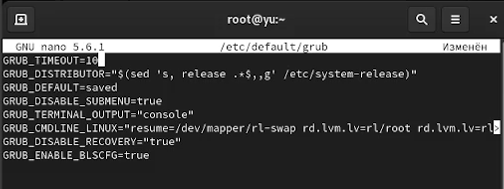

Выполнили пункты 1 и 2 из раздела 11.4.1. (Модификация параметров GRUB2)

## Выполнение лабораторной работы

Записали изменения в GRUB2, перезагрузили систему и убедились, что при загрузке видим прокрутку загрузочных сообщений

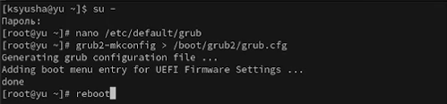

Выполнили пункты 3 и 4 из раздела 11.4.1. (Модификация параметров GRUB2)

## Выполнение лабораторной работы

Перегрузили систему. Изменили строку с linux ($root)/vmlinuz-. Эта строка загружает ядро системы. В конце этой строки ввели systemd.unit=rescue.target и удалили опции rhgb и quit из этой строки

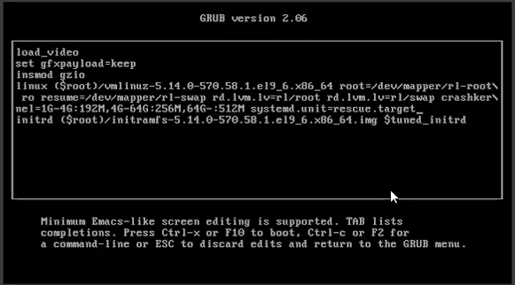

Выполнили пункты 1-3 из раздела 11.4.2. (Устранения неполадок)

## Выполнение лабораторной работы

Ввели пароль пользователя root при появлении запроса. Посмотрели список всех файлов модулей, которые загружены в настоящее время, увидели, что загружена базовая системная среда

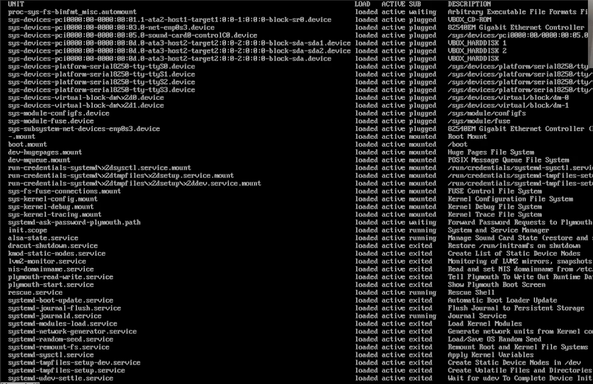

Выполнили пункты 4 и 5 из раздела 11.4.2. (Устранения неполадок)

## Выполнение лабораторной работы

Посмотрели задействованные переменные среды оболочки и перегрузили систему

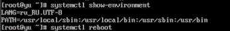

Выполнили пункты 6 и 7 из раздела 11.4.2. (Устранения неполадок)

## Выполнение лабораторной работы

В меню GRUB, ещё раз нажали e на строке с текущей версией ядра, чтобы войти в режим редактора. В конце строки, загружающей ядро, ввели systemd.unit=emergency.target и удалили опции rhgb и quit из этой строки

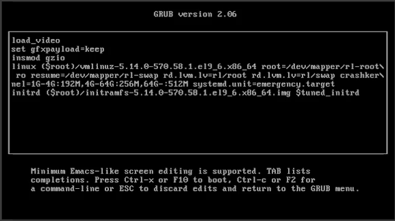

Выполнили пункт 8 и 9 из раздела 11.4.2. (Устранения неполадок)

## Выполнение лабораторной работы

Ввели пароль пользователя root при появлении запроса. После успешного входа в систему посмотрели список всех загруженных файлов модулей. Обратили внимание, что количество загружаемых файлов модулей уменьшилось до минимума. Перегрузили систему

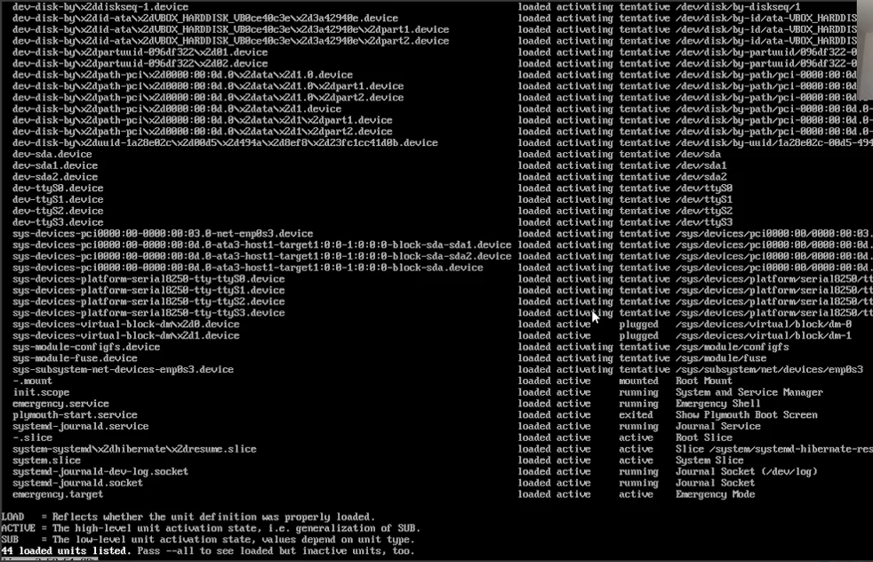

Выполнили пункт 10-12 из раздела 11.4.2. (Устранения неполадок)

## Выполнение лабораторной работы

Перегрузили систему. В меню grub вошли в режим редактора. В конце строки, загружающей ядро, ввели rd.break и удалили опции rhgb и quit

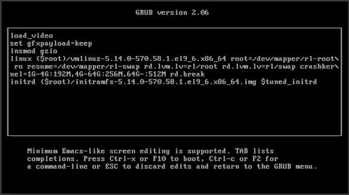

Выполнили пункты 1 и 2 из раздела 11.4.3. (Сброс пароля root)

## Выполнение лабораторной работы

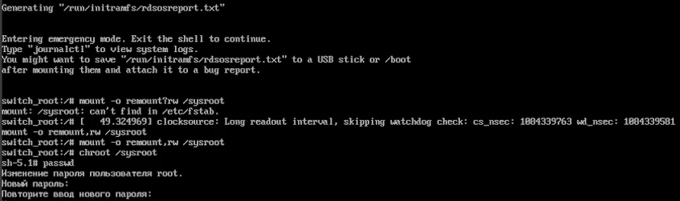

Выполнили пункты 3-6 из раздела 11.4.3. (Сброс пароля root)

## Выполнение лабораторной работы

Загрузили политику SELinux, вручную установили правильный тип контекста для /etc/shadow и перезагрузилите систему с помощью команды reboot -f

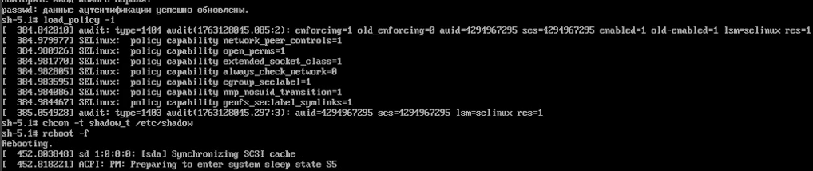

Выполнили пункт 7-9 из раздела 11.4.3. (Сброс пароля root)

## Выполнение лабораторной работы

Вошли в систему с изменённым паролем для пользователя root

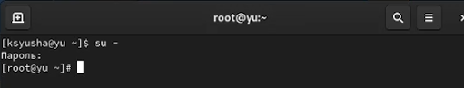

Выполнили пункт 9 из раздела 11.4.3. (Сброс пароля root)

# Выводы

В ходе лабораторной работы мы получили навыки работы с загрузчиком системы GRUB2.